# Racial Disparities in Texas’ Justice System

Elora Hoberecht

02/22/2022

## Introduction

The United States criminal justice system is inherently race-based, targeting minorities since its inception following the emancipation of slaves by the 13th amendment. This historic amendment includes a clause excluding convicts and thus inspiring inventive laws and policies directly targeting non-white minorities, such those against vagrancy, loitering, and the many policies put into motion during the ‘War on Drugs’ movement. The southern US is known for its more conservative ideals and long, storied history with slavery and racism, so for this assignment it seems relevant to focus on Texas: the heart of the south and birthplace of the Juneteenth holiday marking the end of slavery.

## Summary Information

Despite the grim picture this data paints about Texas’ justice system, the overall population of jailed or imprisoned Texans has actually decreased by -4% between 2006 and 2016, indicating an improving overall trend. Because of this data, I decided to focus the rest of this project on Texas specifically, to better understand the impacted populations and identify any significant patterns that might exist in this data set.

## Chart 1: Trends Over Time

This chart is intended to show the different racial groups that make up the population of jailed or imprisoned Texas residents, comparing changes over a ten year period. I chose this specific range (2006 - 2016) because these years contain the most complete data for these racial groups in a large enough time frame to properly illustrate change over time.

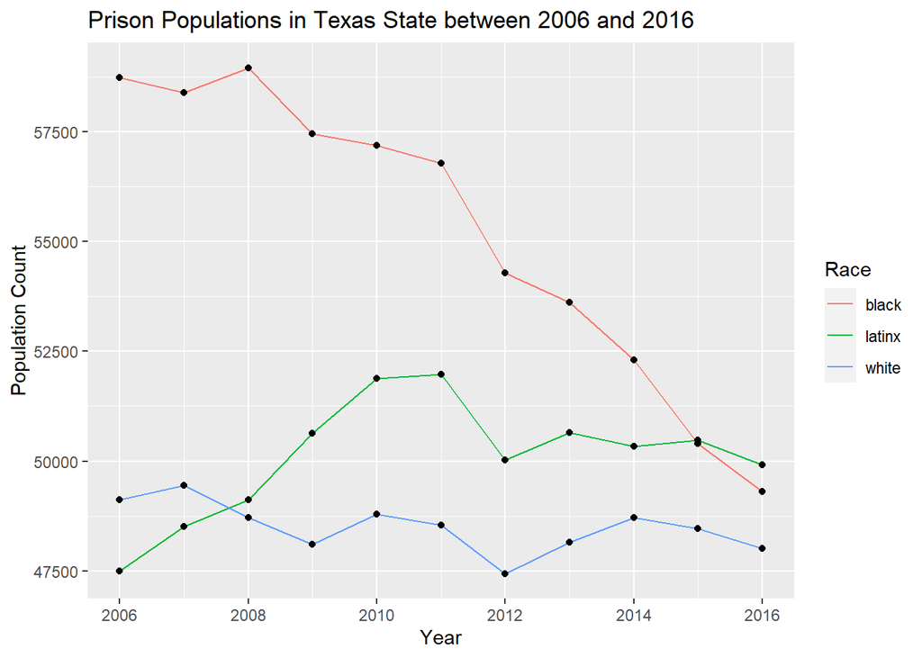

## Chart 2: Comparing Variables

This bar graph takes a look at prison admission rates in Texas, broken down by race and county. I included this chart because it felt important to observe patterns pertaining to new admissions using the most recent data available. This data was filtered to show values from the 5 Texas counties with the highest admission rates for 2016.

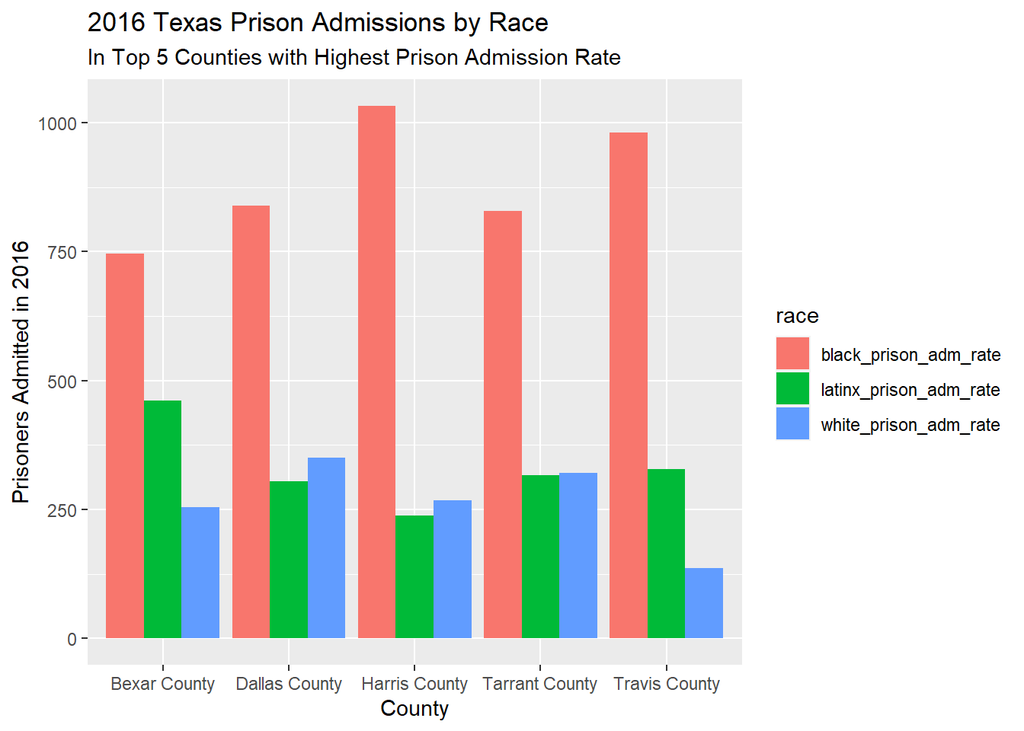

## Chart 3: Mapping Data

This map provides a visual representation showing the distribution of prisoners jailed in Texas that identify as part of the Latinx community. I felt this was important to see if any geographic patterns emerge, potentially bringing new insights and conclusions from this data.

Unfortunately, I didn’t see any obvious patterns. I happen to know from living in Texas that most of these counties with the greatest population of Latinx prisoners also have a very large Latinx community in the broader population. It may be more effective to look at proportions, comparing the proportion of Latinx prisoners in each county, instead of simply looking at total population by race individually.

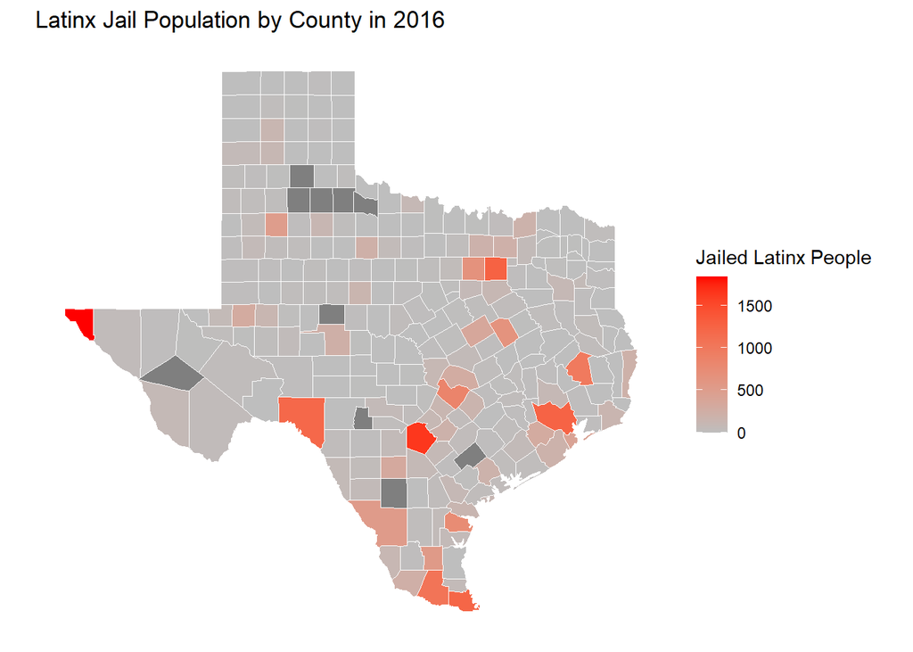